# Association Supplement

James Muguira

April 12, 2016

Let’s work one more example and show how to use the lhs, rhss, support and confidence ratio’s to quickly narrow the rule set to an answer. We are going to follow Salem Marafi’s (http://www.salemmarafi.com/code/market-basket-analysis-with-r/) analysis to start.

First, let’s get the dataset loaded.

```r
library(arules)
```

```r
library(arulesViz)
library(datasets)
data("Groceries")
str(Groceries)
```

```
## Formal class 'transactions' [package "arules"] with 3 slots
##   ..@ data       :Formal class 'ngCMatrix' [package "Matrix"] with 5 slots
##   .. .. ..@ i       : int [1:43367] 13 60 69 78 14 29 98 24 15 29 ...
##   .. .. ..@ p       : int [1:9836] 0 4 7 8 12 16 21 22 27 28 ...
##   .. .. ..@ Dim     : int [1:2] 169 9835
##   .. .. ..@ Dimnames:List of 2
##   .. .. .. ..$ : NULL
##   .. .. .. ..$ : NULL
##   .. .. ..@ factors : list()
##   ..@ itemInfo   :'data.frame':  169 obs. of  3 variables:
##   .. ..$ labels: chr [1:169] "frankfurter" "sausage" "liver loaf" "ham" ...
##   .. ..$ level2: Factor w/ 55 levels "baby food","bags",..: 44 44 44 44 44 44 44 42 42 41 ...
##   .. ..$ level1: Factor w/ 10 levels "canned food",..: 6 6 6 6 6 6 6 6 6 6 ...
##   ..@ itemsetInfo:'data.frame':  0 obs. of  0 variables
```

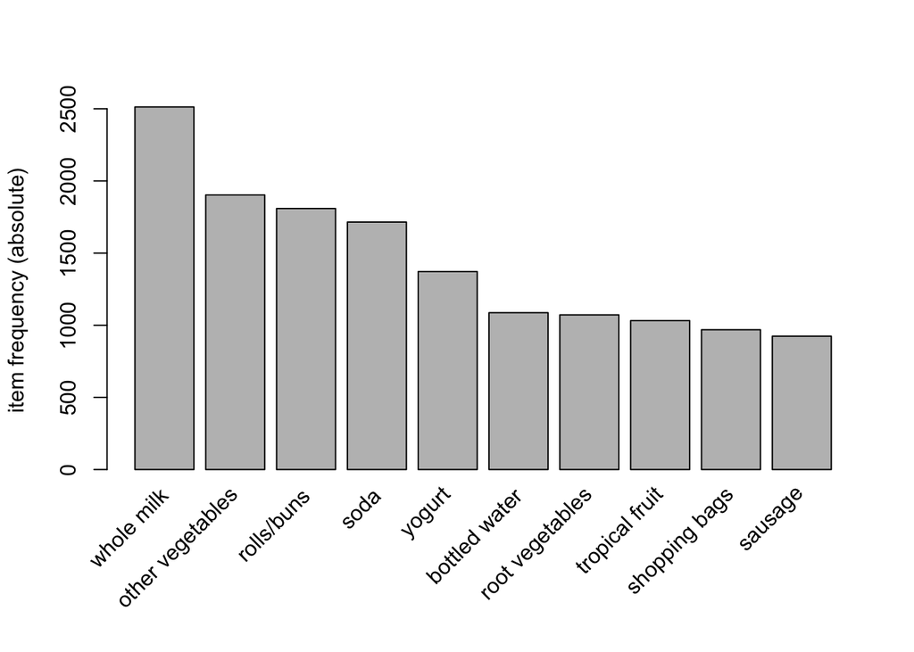

```r
itemFrequencyPlot(Groceries, topN=10, type='absolute')
```

This plot shows that ‘whole milk’ is a popular item to purchase. What we want to know is “what other items are purchased with yogurt?” If we set the confidence low (e.g. conf=0.08) we generate almost 35,000 rules. Explaining that another way, if we want to see all the rules where the conclusion (any premise in this case) occurs at least 8% of the time the algorithm generated 34,927 rules. That is a few too many to sort through by hand. Mr. Marafi leads us through analysis by sorting the rule set and then reducing redundancy and finally targeting a specific right hand side rule. We can quickly narrow this by adding to the parameter list.

*We’ll add the ‘minlen’ parameter to remove rules with a blank lhs.*  
We’ll add the ‘appearance=’ parameter to narrow the search to just yogurt.

```r
rules = apriori(Groceries, parameter=list(supp=0.001, conf=0.08,minlen=2), appearance = list(default='rhs',lhs='yogurt'), control=list(verbose=F))
inspect(rules)
```

```
##    lhs         rhs                     support    confidence lift
## 1  {yogurt} => {cream cheese }         0.01240468 0.08892128 2.242412
## 2  {yogurt} => {frozen vegetables}     0.01240468 0.08892128 1.848924
## 3  {yogurt} => {beef}                  0.01169293 0.08381924 1.597601
## 4  {yogurt} => {curd}                  0.01728521 0.12390671 2.325615
## 5  {yogurt} => {napkins}               0.01230300 0.08819242 1.684218
## 6  {yogurt} => {frankfurter}           0.01118454 0.08017493 1.359518
## 7  {yogurt} => {brown bread}           0.01453991 0.10422741 1.606703
## 8  {yogurt} => {margarine}             0.01423488 0.10204082 1.742312
## 9  {yogurt} => {butter}                0.01464159 0.10495627 1.894027
## 10 {yogurt} => {newspapers}            0.01535333 0.11005831 1.378883
## 11 {yogurt} => {domestic eggs}         0.01433655 0.10276968 1.619775
## 12 {yogurt} => {fruit/vegetable juice} 0.01870869 0.13411079 1.855105
## 13 {yogurt} => {whipped/sour cream}    0.02074225 0.14868805 2.074251
## 14 {yogurt} => {pip fruit}             0.01799695 0.12900875 1.705378
## 15 {yogurt} => {pastry}                0.01769192 0.12682216 1.425481
## 16 {yogurt} => {citrus fruit}          0.02165735 0.15524781 1.875752
## 17 {yogurt} => {shopping bags}         0.01525165 0.10932945 1.109654
## 18 {yogurt} => {sausage}               0.01962379 0.14067055 1.497289
## 19 {yogurt} => {bottled water}         0.02297916 0.16472303 1.490387
## 20 {yogurt} => {tropical fruit}        0.02928317 0.20991254 2.000475
## 21 {yogurt} => {root vegetables}       0.02582613 0.18513120 1.698475
## 22 {yogurt} => {soda}                  0.02735130 0.19606414 1.124368
## 23 {yogurt} => {rolls/buns}            0.03436706 0.24635569 1.339363
## 24 {yogurt} => {other vegetables}      0.04341637 0.31122449 1.608457
## 25 {yogurt} => {whole milk}            0.05602440 0.40160350 1.571735
```

There you are. Given the 9800 odd shopping lists as a starting point we can quickly determine items that are purchased together. In our case or yogurt, the search provided 25 rules. The implication for a small market vendor might be that these items should be stocked so as to maximize the sales when someone is looking for yogurt.